# Analyzing the Star Lifecycle using the Hertzsprung Russell Diagram

Analyzing the Star Lifecycle using the Hertzsprung Russell Diagram Abby Stokes 2024-12-2

## Introduction

There are many different types of stars, including dwarfs, main sequence (like our sun), and giants, each of which represents a star at a different stage in its lifecycle. All stars begin as a cloud of molecules, or space dust, which slowly collapse together to form a star. The way a star further evolves into different types depends largely on its starting mass. Stars with low mass are more likely to develop into dwarf stars, whereas highly massive stars are more likely to evolve into a super or hyper giant.

[figure not shown]

Stars begin their life very hot and bright, and as they lose energy over the course of their life, they begin to cool down and become dimmer. Eventually, when a star loses enough energy, it will either shrink into a dwarf or grow to a giant, and eventually die through a supernova or, in rarer cases, become a neutron star or black hole. Stars that are in the regular course of their life cycle are referred to as “main sequence” stars, which typically fall within a specific range of absolute magnitude (brightness) and temperature. The following image demonstrates this process in more detail:

[figure not shown]

The Hertzprung-Russell diagram from astrophysics shows the relationship between absolute magnitude and temperature. It is an effective way to visualize the star lifecycle. To understand the HR diagram, we must first discuss what the absolute magnitude of a star means and how we measure it. Absolute Magnitude is a measure of the true “brightness” of a star. This is different than luminosity, which is how bright the star appears on earth to our telescopes (further away stars appear dimmer, but may actually be brighter). However, Absolute Magnitude can be calculated using a combination of luminosity and distance.

An important and somewhat counter-intuitive note about the absolute magnitude scale is that smaller values correspond to a brighter star. For this reason, the HR plots in this report will invert the y-axis to make interpretability easier. The following shows an example HR diagram, which illustrates the relationship between temperature (spectral type) on the x-axis, absolute magnitude on the y-axis, and how each star type falls into a specific sector on this diagram:

[figure not shown]

Our goal will be to recreate this diagram using a sample of star data, along with other data visualizations, to better understand the relationship between different star variables and their type, with the ultimate goal of creating a classification model for predicting star type.

## Dataset

The Star Dataset used for this analysis comes from [Kaggle](https://www.kaggle.com/datasets/deepu1109/star-dataset), and includes information on 240 different stars, evenly distributed across 6 different star types (40 each). Star types are as follows:

- Brown Dwarf
- Red Dwarf
- White Dwarf
- Main Sequence
- Supergiant
- Hypergiant

Each observation contains 7 star attributes including

- Absolute Temperature (in K)
- Relative Luminosity (L/Lo)
- Relative Radius (R/Ro)
- Absolute Magnitude (Mv)
- Star Color (white,Red,Blue,Yellow,yellow-orange etc.)
- Spectral Class (O,B,A,F,G,K,,M)
- Star Type (Red Dwarf, Brown Dwarf, White Dwarf, Main Sequence , SuperGiants, HyperGiants)

```r
stars <- read.csv("data/StarData.csv", header=TRUE)
stars <- tibble(stars)
head(stars)
```

```
## # A tibble: 6 × 7
##   Temperature..K. Luminosity.L.Lo. Radius.R.Ro. Absolute.magnitude.Mv. Star.type
##             <int>            <dbl>        <dbl>                  <dbl>     <int>
## 1            3068         0.0024          0.17                    16.1         0
## 2            3042         0.0005          0.154                   16.6         0
## 3            2600         0.0003          0.102                   18.7         0
## 4            2800         0.0002          0.16                    16.6         0
## 5            1939         0.000138        0.103                   20.1         0
## 6            2840         0.00065         0.11                    17.0         0
## # ℹ 2 more variables: Star.color <chr>, Spectral.Class <chr>
```

Questions of Interest:

We are interested in using this dataset to examine the relationship between star variables. Specifically, we want to see if we can use variables such as color, temperature, size, etc. to predict a star type. The HR diagram attempts to do this through plotting several star features in one places, allowing us to visually group and distinguish the different types.

## Data Pre Processing

1. Re-code star type: Add a new column that maps from the number to the star name.

```r
# Add column for name based on star type and categor
star_type_map <- c(
  "0" = "Brown Dwarf",
  "1" = "Red Dwarf",
  "2" = "White Dwarf",
  "3" = "Main Sequence",
  "4" = "Supergiant",
  "5" = "Hypergiant"
)
stars <- stars %>%
  mutate(StarName = star_type_map[as.character(Star.type)],
         StarCategory = case_when(
           Star.type %in% c(0, 1, 2) ~ "Dwarfs",
           Star.type == 3 ~ "Main Sequence",
           Star.type %in% c(4, 5) ~ "Giants"
         ))
stars %>%
  select(Star.type,StarName,StarCategory) %>%
  distinct()
```

```
## # A tibble: 6 × 3
##   Star.type StarName      StarCategory
##       <int> <chr>         <chr>
## 1         0 Brown Dwarf   Dwarfs
## 2         1 Red Dwarf     Dwarfs
## 3         2 White Dwarf   Dwarfs
## 4         3 Main Sequence Main Sequence
## 5         4 Supergiant    Giants
## 6         5 Hypergiant    Giants
```

2. Set desired order of factor variables based on star size (Order them from small to large)

```r
stars$Star.type <- factor(stars$Star.type, levels = c(2,0, 1, 3, 4, 5))  # Set the desired order
stars$StarName <-  factor(stars$StarName, levels = c("White Dwarf",
                                                    "Brown Dwarf",
                                                    "Red Dwarf",
                                                    "Main Sequence",
                                                    "Supergiant",
                                                    "Hypergiant"))
```

3. Add a column for plotting based on true star color. Clean up the color column, and create a mapping to its HTML color value for later use.

```r
# Clean the color column names
stars <- stars %>%
  mutate(Star.color = Star.color %>%
           # Convert to lowercase
           tolower() %>%
           # Trim leading/trailing whitespace
           trimws() %>%
           # Replace hyphens with single hyphen
           gsub("[- ]+", "-", .) %>%
           # Other cases
           gsub("yellowish", "yellow", .) %>%
           gsub("whitish", "white", .)
  )

unique(stars$Star.color)
```

```
##  [1] "red"                "blue-white"         "white"
##  [4] "yellow-white"       "pale-yellow-orange" "blue"
##  [7] "orange"             "white-yellow"       "yellow"
## [10] "orange-red"
```

```r
# Now add a column with the HTML code for each cleaned color
color_map <- c(
  "red" = "#FF0000",
  "blue-white" = "#ADD8E6",
  "white" = "#FFFFFF",
  "yellow-white" = "#FFFFE0",
  "pale-yellow-orange" = "#FFDAB9",
  "blue" = "#0000FF",
  "orange" = "#FFA500",
  "white-yellow" = "#FFFFE0",
  "yellow" = "#FFFF00",
  "orange-red" = "#FF4500"
)

stars <- stars %>%
  mutate(HTMLColor = color_map[Star.color])
```

## Results

Now that the data is pre-processed and we have all our relevant columns, let us take a look at some tables/visuals to address our research questions!

### Table 1

Research Question 1: How do the average values for our numerical variables vary accross star types?

Summary of Star Dataset

[output not shown]

Interpretation:

As we can see in the above table, the average radius is smallest for our dwarf stars, and largest for the giants. Further, the average temperature in degrees Kelvin does not appear to follow a straightforward trend from small to large stars, as our White dwarf stars are about as hot on average as the giants. Main sequence stars are the hottest, which aligns with scientific knowledge about star lifecycles. Finally, absolute magnitude is smallest (meaning brightest) for our giants, and largest (meaning dimmest) for the dwarfs. This makes sense as the smaller stars have less overall energy to transmit across space to be picked up by our detectors on earth, meaning they appear dimmer. Finally, we confirm that there is an equal count of all stars in the dataset - 40.

### Data Viz 1

Research Question 2: How does the size of a star vary across star types?

[figure not shown]

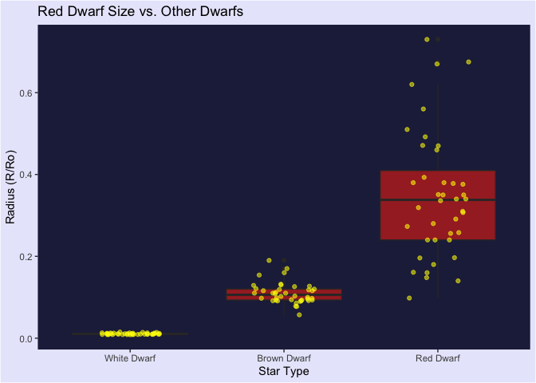

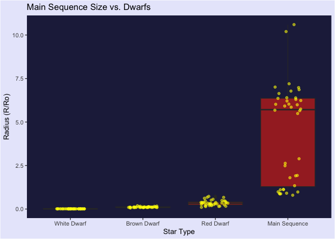

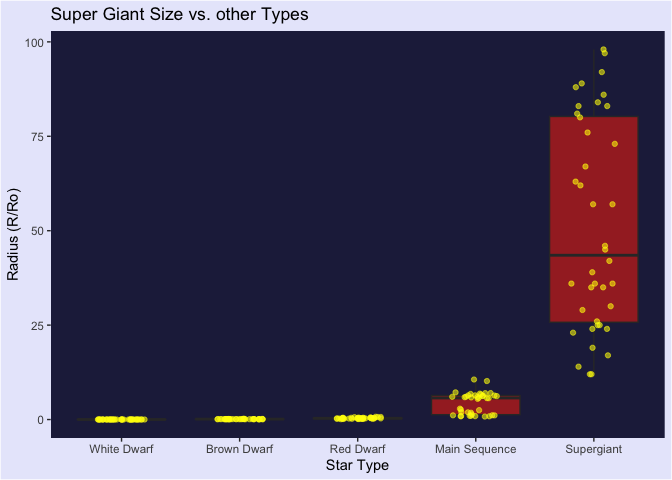

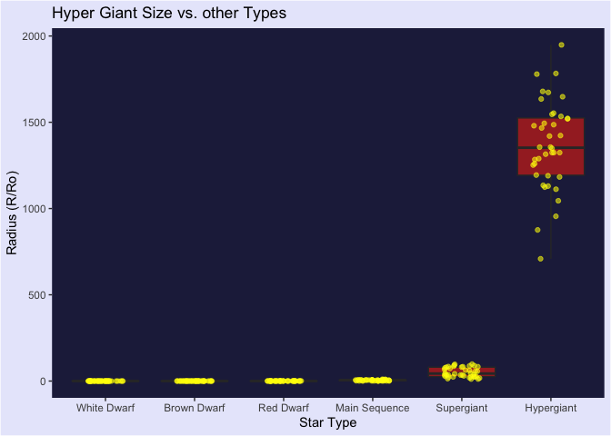

Interpretation:

As you can see from these visualizations, the size of each type of star increases exponentially as we move along each star type. A good way to visualize this exponential relationship is to plot using a log scale on the Y-axis. The resulting relationship should be approximately linear. The following plot shows this to be true.

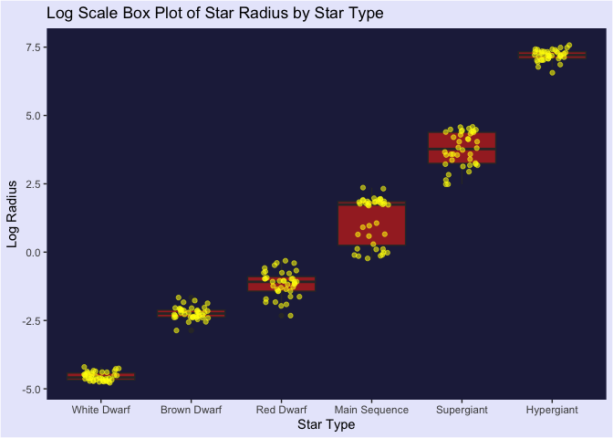

Interpretation:

We see that there is very little overlap / outliers between classes with the log radius scale. This shows that only by knowing the radius of a given star, we are able to reasonably predict it’s type.

### Data Viz 2

Now that we better understand the relationship between star types and their size, let’s look at temperature. Are the biggest stars also the hottest? Let’s find out!

Note about colors: While it may be counter intuitive, when it comes to burning gases, such as stars, the color blue is hottest (think of a blowtorch), and red is coolest (think of a candle)

Research Question 3: How does the temperature of a star vary across star types?

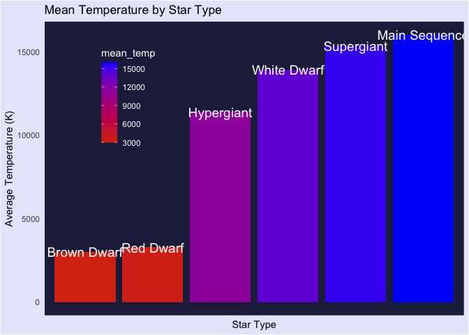

Interpretation:

Something that may be surprising in this chart is that White Dwarfs are hotter on average than Hypergiants, even though they are actually the smallest star type, and are the result of a red dwarf collapsign in on itself. This is due to the fact that white dwarfs are extremely dense, with all of their mass condensed into a small space. This causes them to be extremely hot, despite their small size and relatively small mass.

The conclusion here is that while star size is a good predictor of type, temperature is not, as it varies quite widely across all star types.

### Data Viz 3

Now that we have a good understanding of the relationship between star type, temperature, and size, let’s look at brightness (in the form of absolute magnitude). We will try to reproduce the HR Diagram, which shows the relationship between absolute brightness and temperature. We will include information on star size (point size) and type (point color) as well.

Note about inverted axes: We will be plotting temperature inverted on the X axis (high to low), in order to represent the star life cycle going from hot to cold. Also remember that the Y axis of absolute magnitude will be inverted as well to show that smaller values represent brighter stars

Research Question 4: What is the relationship between star brightness, temperature, and type?

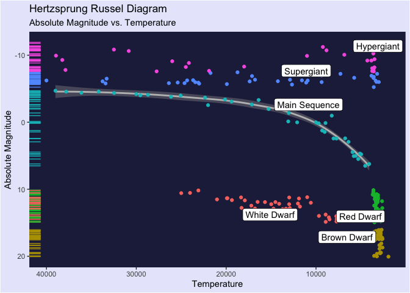

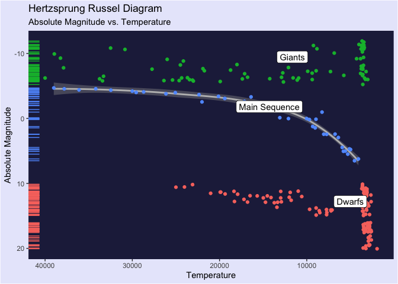

Interpretation:

As we can see by the above visual, our star data closely follow the expected pattern for HR diagrams, with the giants being the brightest, and dwarfs being the dimmest. We also see the using temperature as a proxy for time on the X axis (stars beign their life hot and cool down before dying), we can see the progression of main sequence stars from bright to dimmer. The carpet diagram shows that there is a pretty clear distinction between the three big types (giant, dwarf, main sequence) just by using absolute magnitude, as there is no color overlap in the second chart. Finally, the charts show a clustering of stars at the right end of the temperature spectrum (cool), which is primarily dominated by Giants and Dwarf stars. This aligns with scientific knowledge that these stars are end of life, and thus cooler on average than their main sequence counterparts.

### Bonus Data Viz!

A cool variable in this dataset is the color column, which was created by the dataset owner by manually going through images of each star and classifying the true color. I wanted to create a mapping of these colors to a plot, and see if it aligns with the HR Diagram expectations. I did this in the data pre-processing step by assigning an html color code to each row based on the observed color, and mapping this to the color aesthetic in the plot. We can see a trend of cooler stars (more red) grouping towards the right hand side of the plot, as they are further along in their lifecycle and have lost more energy. We also see an interesting journey along the main sequence with stars starting out blue and bright, and slowly becoming dimmer and redder.

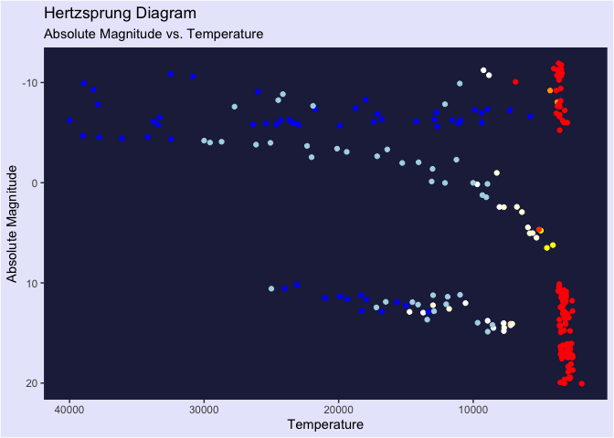

## Conclusions and Future Work

For future work, I think it would be of interest to perform further analysis to build a classification model that is able to predict star type based on attributes such as color, temperature, absolute magnitude, etc. We could use techniques such as logistic regression, decision tree, SVM, etc. and compare accuracy metrics to choose the best model. This could be helpful for Astronomers / physicists who are interested in a quick way to classify star type using readily available information.

In conclusion, this star dataset very closely followed the patterns as predicted by the Hertzsprung Russel diagram and star lifecycle theory, and the HR diagram is a very effective way to portray many different aspects of a given star (color, size, temperature, age, and type) in just one chart!

## References

1. The Star Dataset used for this analysis comes from [Kaggle](https://www.kaggle.com/datasets/deepu1109/star-dataset)
2. I also used the [Wikipedia](https://en.wikipedia.org/wiki/Hertzsprung%E2%80%93Russell_diagram) page for Hertzsprung Russell Diagrams for images and reference material regarding HR Diagrams and the star lifecycle.